# Supplementary Figures

Alex Pate

2024-09-27

Associated with manuscript: Agreement between heuristic shrinkage factor and optimal shrinkage factors in logistic regression for risk prediction: a simulation study across different sample sizes and settings

We present plots from simulation study 1 where:

- Scenarios where data was simulated with a zero-covariance matrix
- Plots presented by $R^{2}_{CS,app}$ and $C_{app}$, as opposed to $R^{2}_{CS,pop}$ and $C_{pop}$.
- Median instead of mean

**Figure S1: mean($S_{VH}$) plotted against mean($S_{opt}$), non-zero covariance in DGM, presented with respect to population-level model performance**

*Estimator = mean($S_{VH}$)*

*Covariance structure = non-zero covariance in DGM*

*By variable = presented with respect to population-level model performance*

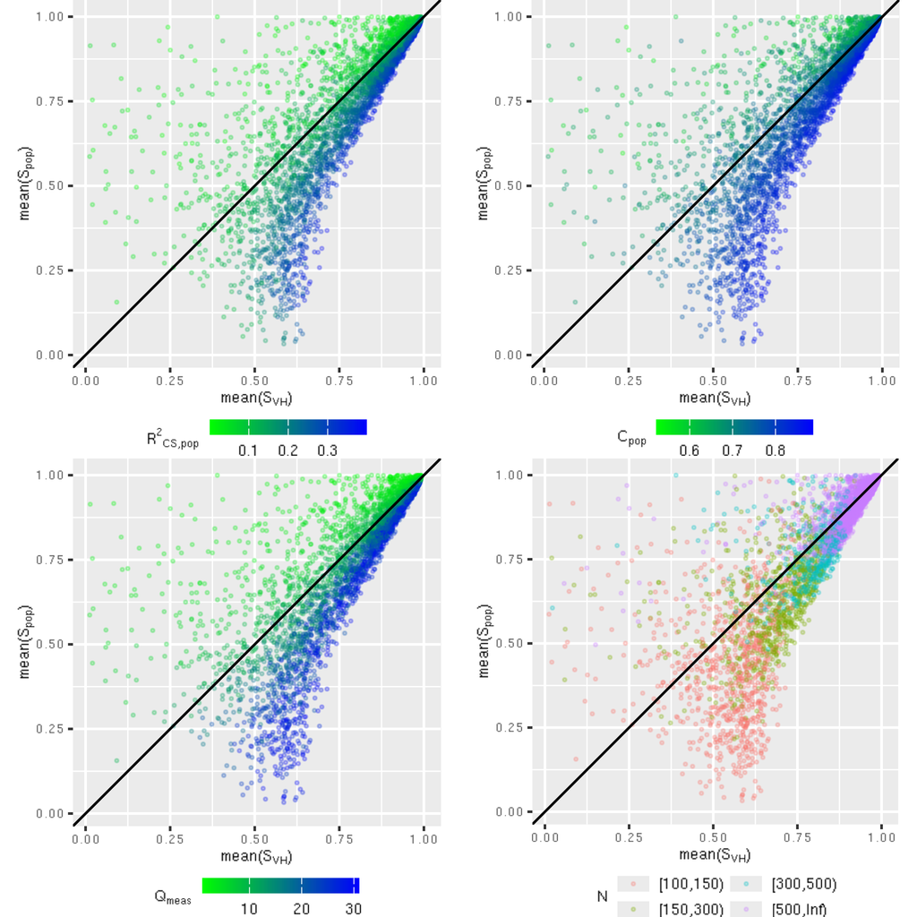

**Figure S2: mean($S_{VH}$) plotted against mean($S_{opt}$), non-zero covariance in DGM, presented with respect to apparent model performance**

*Estimator = mean($S_{VH}$)*

*Covariance structure = non-zero covariance in DGM*

*By variable = presented with respect to apparent model performance*

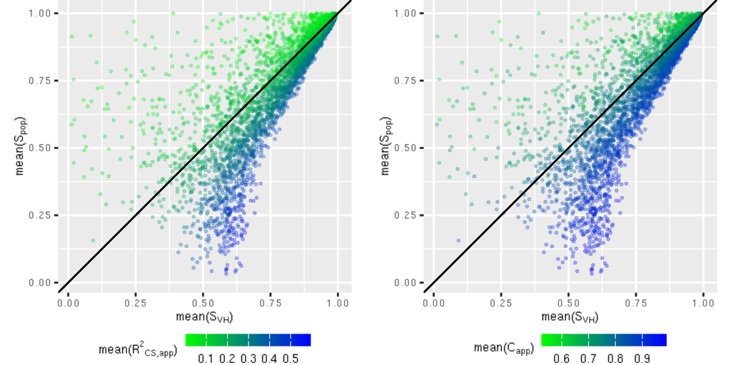

**Figure S3: median($S_{VH}$) plotted against median($S_{opt}$), non-zero covariance in DGM, presented with respect to population-level model performance**

*Estimator = median($S_{VH}$)*

*Covariance structure = non-zero covariance in DGM*

*By variable = presented with respect to population-level model performance*

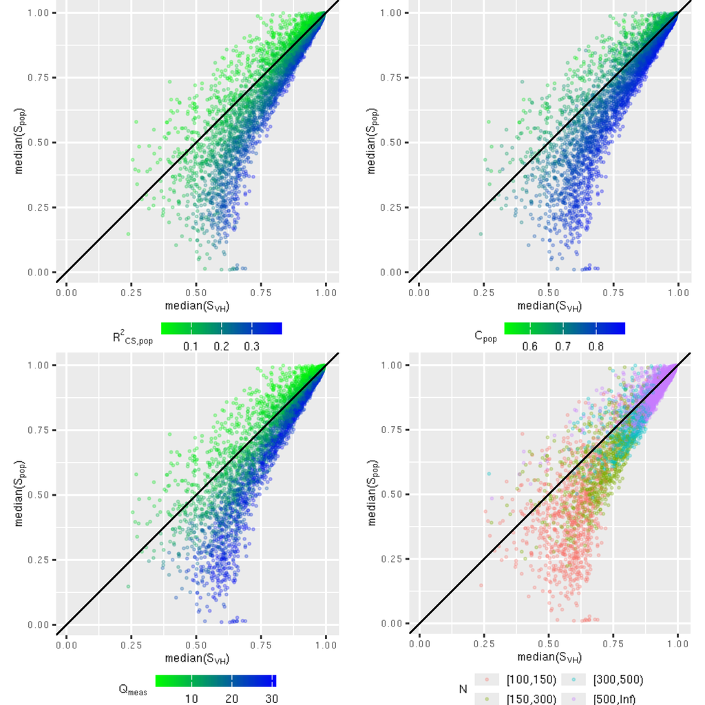

**Figure S4: median($S_{VH}$) plotted against median($S_{opt}$), non-zero covariance in DGM, presented with respect to apparent model performance**

*Estimator = median($S_{VH}$)*

*Covariance structure = non-zero covariance in DGM*

*By variable = presented with respect to apparent model performance*

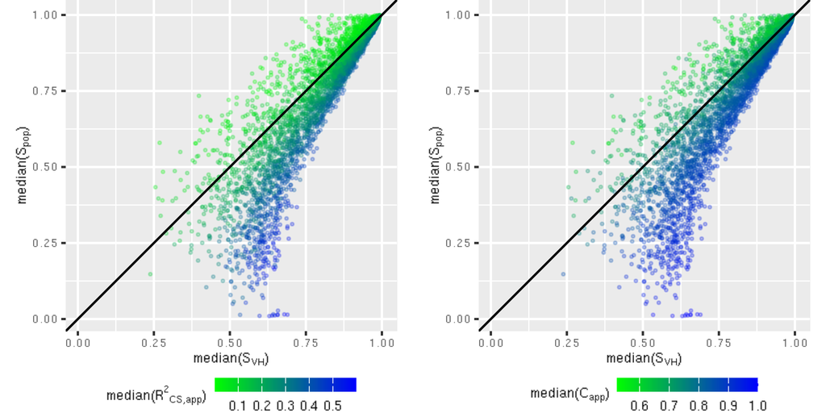

**Figure S5: mean($S_{boot}$) plotted against mean($S_{opt}$), non-zero covariance in DGM, presented with respect to population-level model performance**

*Estimator = mean($S_{boot}$)*

*Covariance structure = non-zero covariance in DGM*

*By variable = presented with respect to population-level model performance*

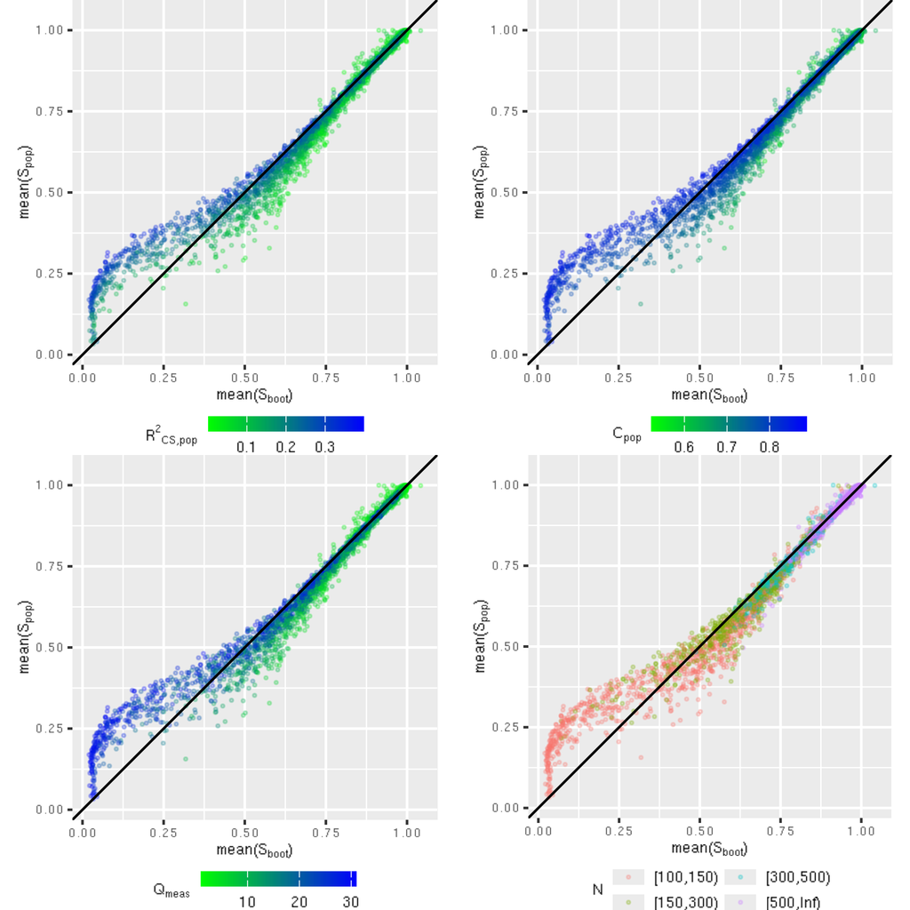

**Figure S6: mean($S_{boot}$) plotted against mean($S_{opt}$), non-zero covariance in DGM, presented with respect to apparent model performance**

*Estimator = mean($S_{boot}$)*

*Covariance structure = non-zero covariance in DGM*

*By variable = presented with respect to apparent model performance*

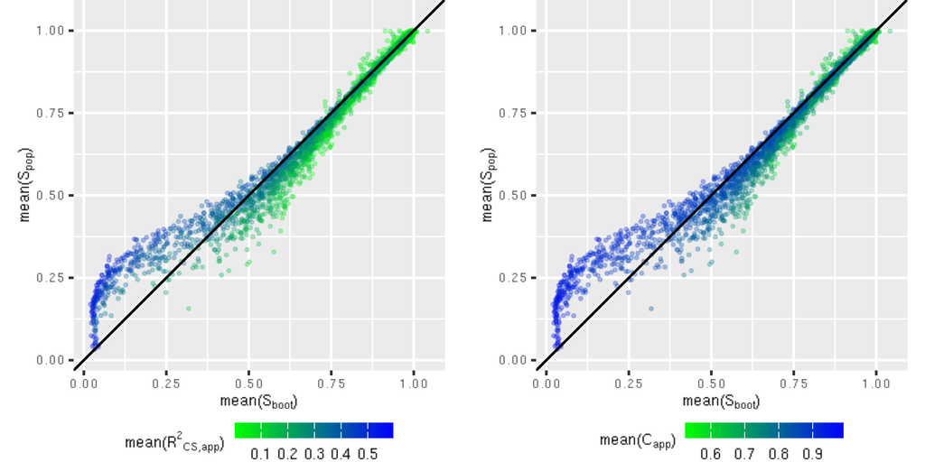

**Figure S7: median($S_{boot}$) plotted against median($S_{opt}$), non-zero covariance in DGM, presented with respect to population-level model performance**

*Estimator = median($S_{boot}$)*

*Covariance structure = non-zero covariance in DGM*

*By variable = presented with respect to population-level model performance*

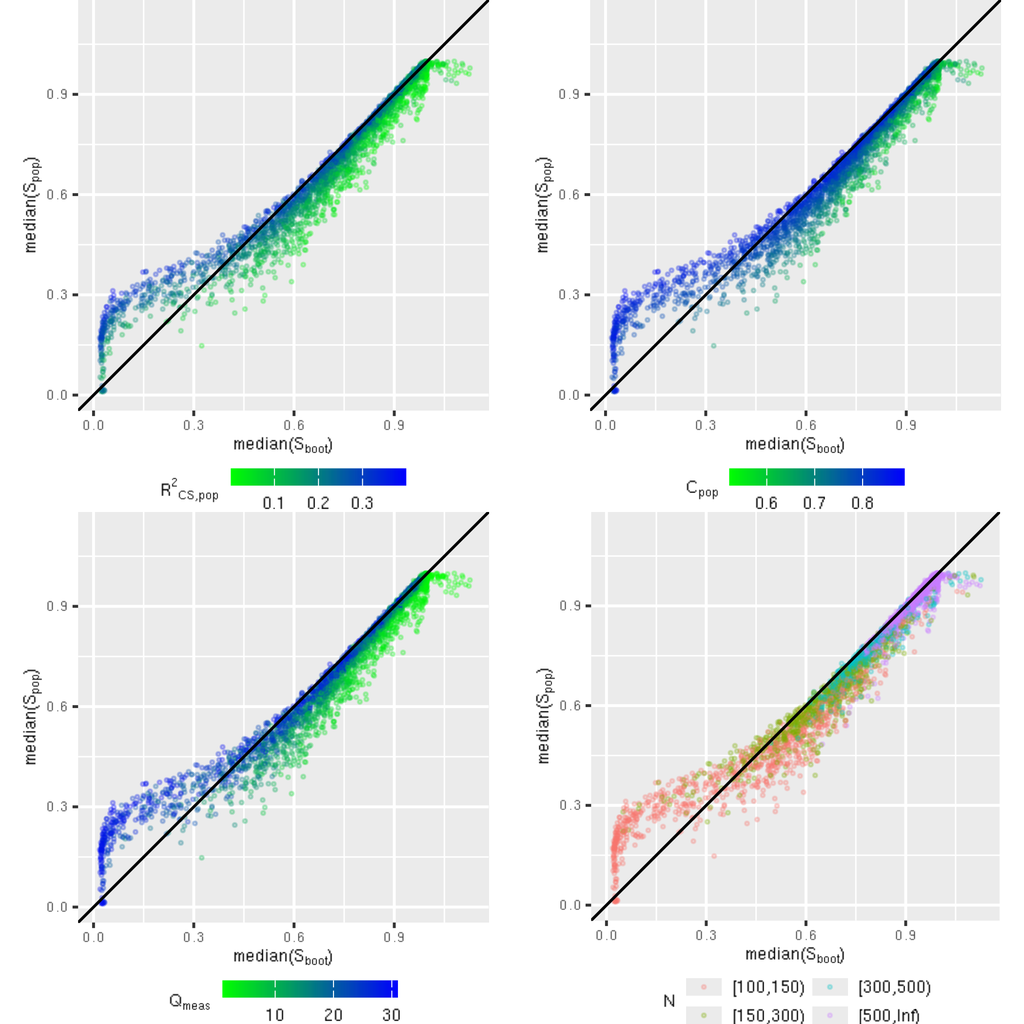

**Figure S8: median($S_{boot}$) plotted against median($S_{opt}$), non-zero covariance in DGM, presented with respect to apparent model performance**

*Estimator = median($S_{boot}$)*

*Covariance structure = non-zero covariance in DGM*

*By variable = presented with respect to apparent model performance*

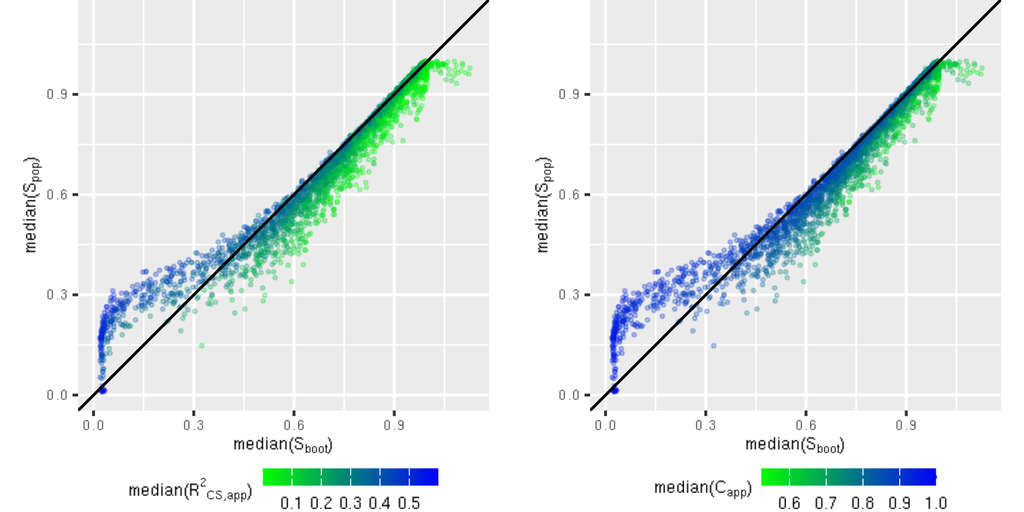

**Figure S9: mean($S_{VH}$) plotted against mean($S_{opt}$), zero covariance in DGM, presented with respect to population-level model performance**

*Estimator = mean($S_{VH}$)*

*Covariance structure = zero covariance in DGM*

*By variable = presented with respect to population-level model performance*

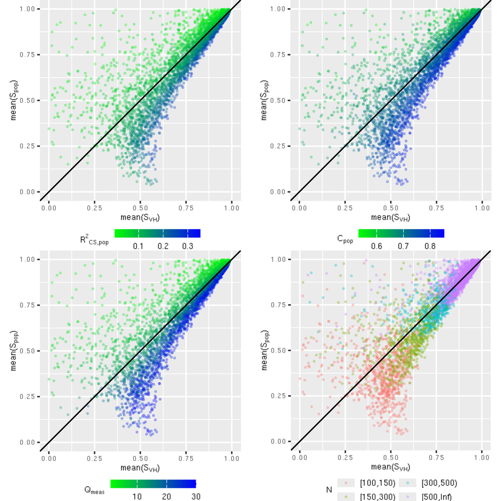

**Figure S10: mean($S_{VH}$) plotted against mean($S_{opt}$), zero covariance in DGM, presented with respect to apparent model performance**

*Estimator = mean($S_{VH}$)*

*Covariance structure = zero covariance in DGM*

*By variable = presented with respect to apparent model performance*

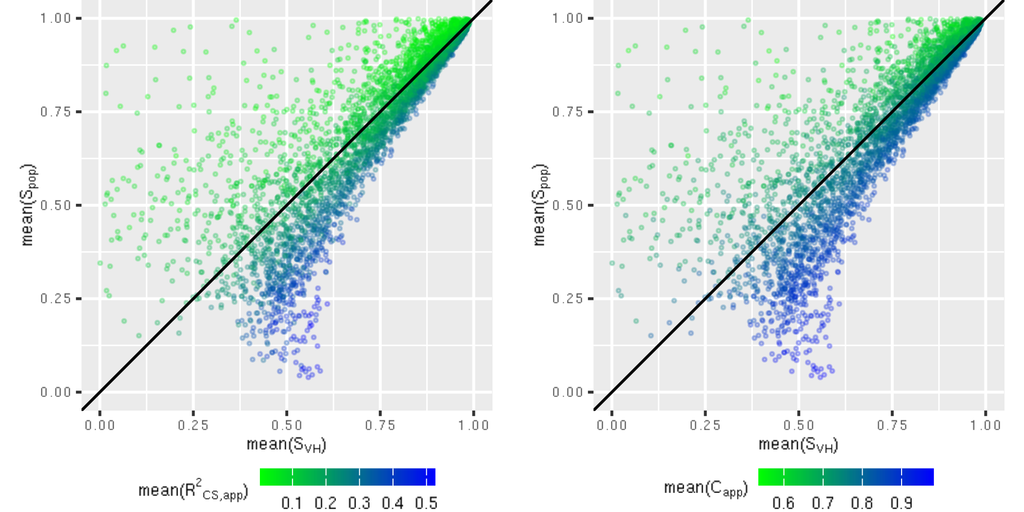

**Figure S11: median($S_{VH}$) plotted against median($S_{opt}$), zero covariance in DGM, presented with respect to population-level model performance**

*Estimator = median($S_{VH}$)*

*Covariance structure = zero covariance in DGM*

*By variable = presented with respect to population-level model performance*

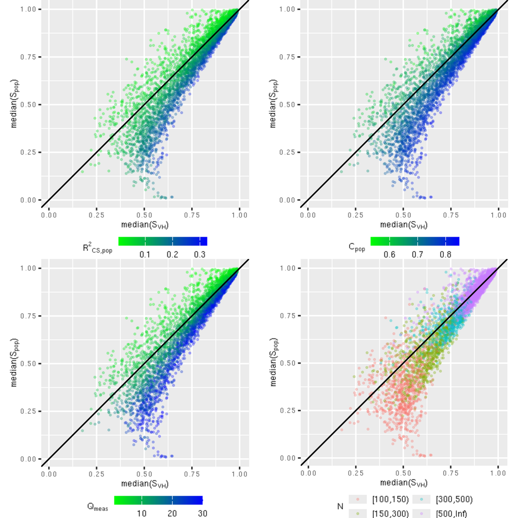

**Figure S12: median($S_{VH}$) plotted against median($S_{opt}$), zero covariance in DGM, presented with respect to apparent model performance**

*Estimator = median($S_{VH}$)*

*Covariance structure = zero covariance in DGM*

*By variable = presented with respect to apparent model performance*

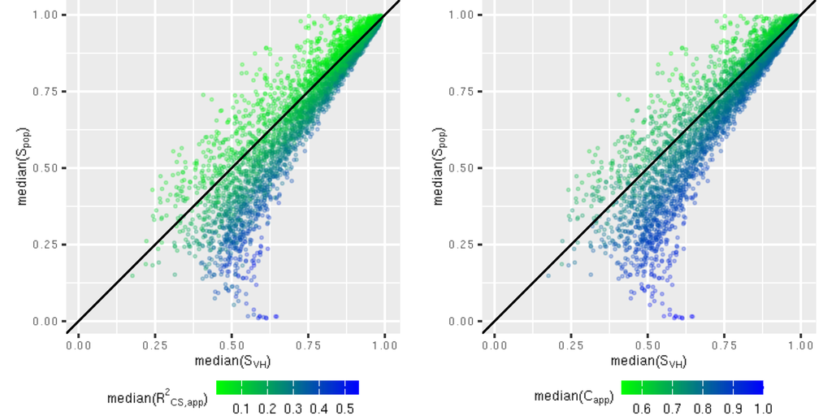

**Figure S13: mean($S_{boot}$) plotted against mean($S_{opt}$), zero covariance in DGM, presented with respect to population-level model performance**

*Estimator = mean($S_{boot}$)*

*Covariance structure = zero covariance in DGM*

*By variable = presented with respect to population-level model performance*

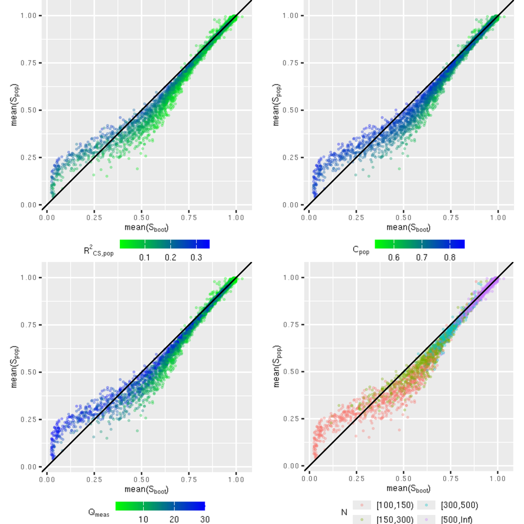

**Figure S14: mean($S_{boot}$) plotted against mean($S_{opt}$), zero covariance in DGM, presented with respect to apparent model performance**

*Estimator = mean($S_{boot}$)*

*Covariance structure = zero covariance in DGM*

*By variable = presented with respect to apparent model performance*

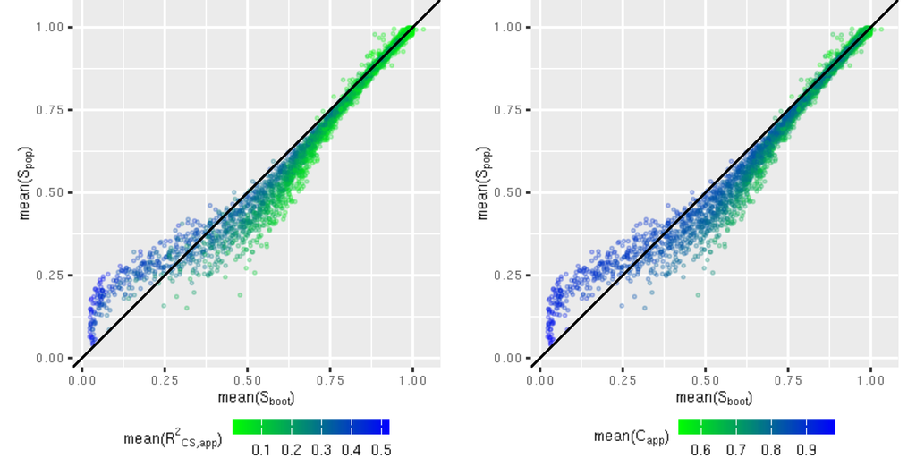

**Figure S15: median($S_{boot}$) plotted against median($S_{opt}$), zero covariance in DGM, presented with respect to population-level model performance**

*Estimator = median($S_{boot}$)*

*Covariance structure = zero covariance in DGM*

*By variable = presented with respect to population-level model performance*

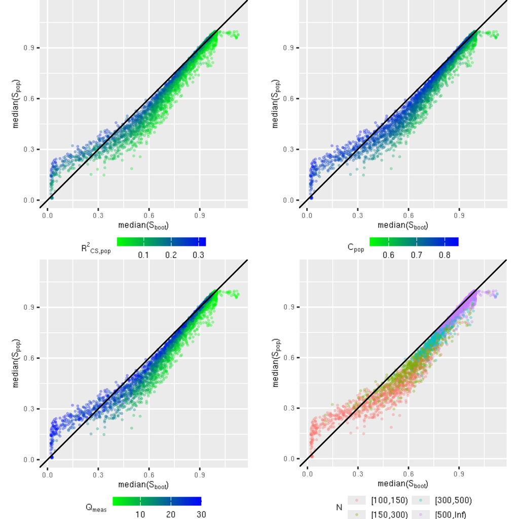

**Figure S16: median($S_{boot}$) plotted against median($S_{opt}$), zero covariance in DGM, presented with respect to apparent model performance**

*Estimator = median($S_{boot}$)*

*Covariance structure = zero covariance in DGM*

*By variable = presented with respect to apparent model performance*

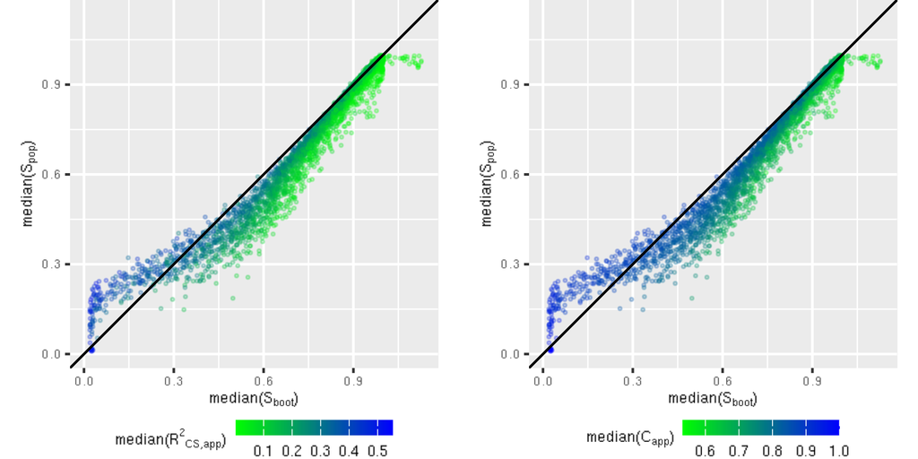

**Figure S17: mean($S_opt$) plotted against mean($S_opt$), grouped by mean($C_app$), non-zero covariance in DGM**

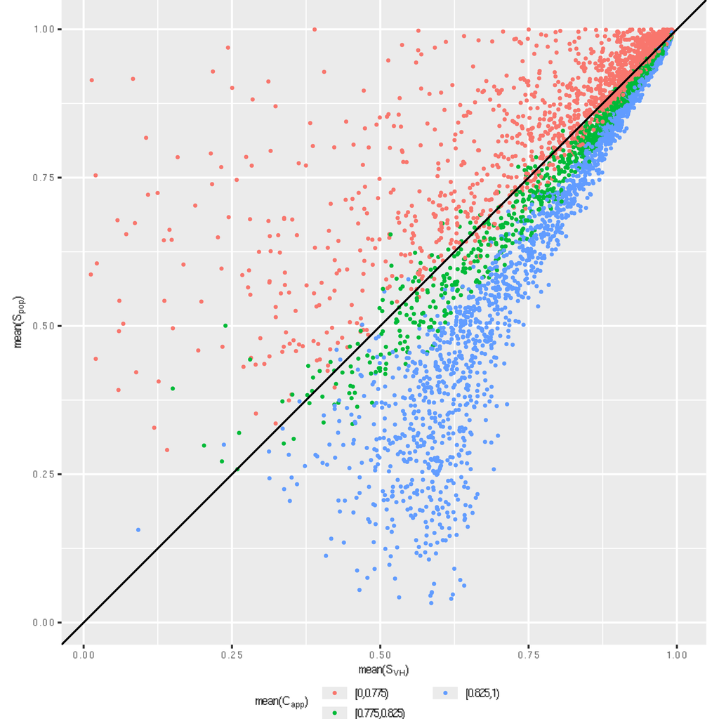

**Figure S18: mean($S_opt$) plotted against mean($S_opt$), grouped by $C_pop$, non-zero covariance in DGM**

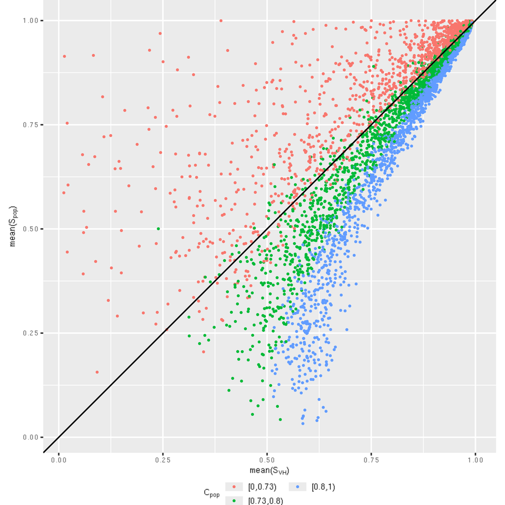

**Figure S19: mean($S_opt$) plotted against mean($S_opt$), grouped by mean($C_app$), zero covariance in DGM**

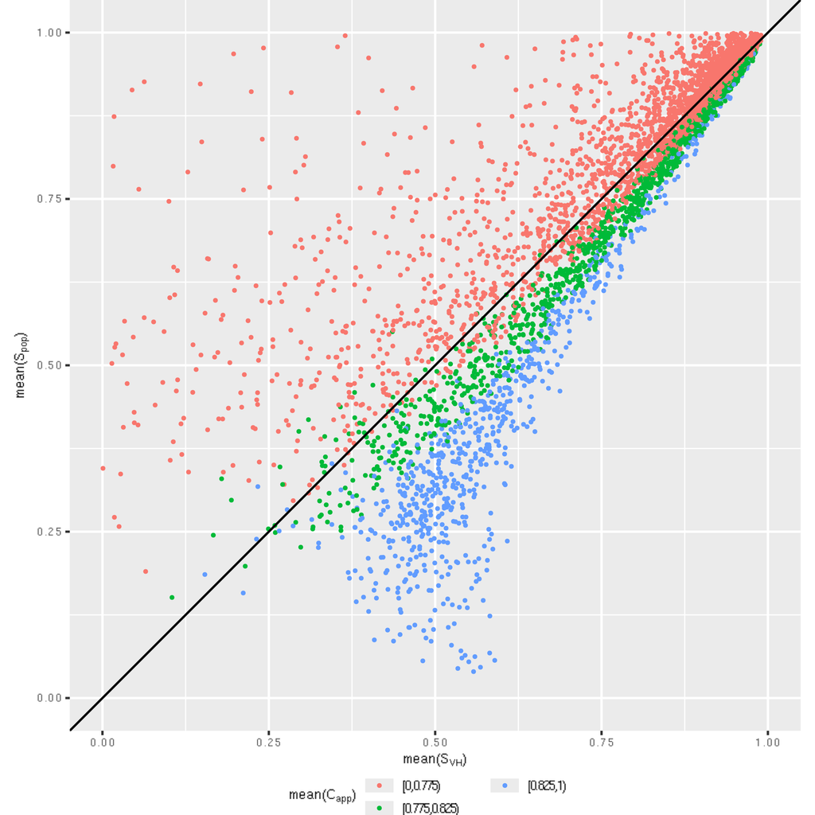

[figure not shown]